# decision tree

## 1 Individual Assignment

**Instructions:** This exercise should be done “by hand”, that is, not using Python. All necessary calculations should be included in the submission, as well as brief explanations of what you do. The training data set in Table 1 on the next page provides a summary of the traffic conditions experienced on a major road across several days, times and weather conditions.

### 1. Create a full classification tree that estimates the traffic based on the day of the week, time of the day and the weather condition. Use the entropy as a purity measure to guide your splitting choices.

[figure not shown]

We'll calculate first entropy of traffic class(Yes/No).

P(Yes) = 11 N(No) = 14

Entropy(Class-traffic) = -P/(P+N) *log(P/(P+N)) - N/(P+N)*log(N/(P+N)) **Note:** All logs refer to base 2.

= -11/25 *log(11/25) - 14/25* log(14/25)

= -0.44 *-1.184 - 0.56* 0.836

= 0.52 + 0.468

= 0.988

Now we'll calculate Information Gain(I.G) for each class of each attributes.

**Attribute 1:** day

| day | P(Yes) | N(No) |
| --- | --- | --- |
| Weekday | 7 | 13 |
| Weekend | 4 | 1 |

I.G(Weekday) = -Pi/(Pi+Ni) *log(Pi/(Pi+Ni)) - Ni/(Pi+Ni)*log(Ni/(Pi+Ni))

= -7/20 *log(7/20) - 13/20* log(13/20)

= -0.35 *log(0.35) - 0.65* log(0.65)

= (-0.35 *-1.514) - (0.65* -0.621)

= 0.5299 + 0.4036

=0.9355

I.G(Weekend)

= -4/5 *log(4/5) - 1/5* log(1/5)

= (-0.8 *-0.321) - (0.2* -2.321)

= 0.2568 + 0.4642

= 0.721

Entropy(day) = sigma((Pi+Ni)/P+N * I.G(Pi,Ni))

= 20/25 *0.9355 + 5/25* 0.721

= 0.8 *0.9355 + 0.2* 0.721

= 0.7484 + 0.144

= 0.8926

Gain(day) = Entropy(class) - Entropy(day)

= 0.988 - 0.8926

= 0.0954

**Attribute 2:** Weather

| Weather | P(Yes) | N(No) |
| --- | --- | --- |
| Sunny | 5 | 13 |
| Rainy | 6 | 1 |

I.G(Sunny)

=-5/18 *log(5/18) - 13/18* log(13/18)

= (-0.277 *-1.852) - (0.722* -0.469)

= 0.513 + 0.338

= 0.851

I.G(Rainy)

= -6/7 *log(6/7) - 1/7* log(1/7)

= (-0.857 *-0.222) - (0.142* -2.816)

= 0.190 + 0.399

= 0.589

Entropy(Weather) =

= 18/25 *0.851 + 7/25* 0.859

= 0.72 *0.851 + 0.28* 0.589

= 0.614 + 0.164

=0.778

Gain(Weather) = Entropy(Class) - Entropy(Weather)

= 0.988 - 0.778

0.210

**Attribute 3:** time

| time | P(Yes) | N(No) |
| --- | --- | --- |
| 1 pm | 6 | 7 |
| 8 am | 5 | 7 |

I.G(1 pm) =

= -6/13 *log(6/13) - 7/13* log(7/13)

=(-0.461 *-1.117) - (0.538* -0.894)

= 0.514 + 0.480

=0.997

I.G(8 am) =

= -5/12 *log(5/12) - 7/12* log(7/12)

= (-0.416 *-1.265) - (0.583* -0.778)

= 0.526 + 0.453

=0.979

Entropy(time)

= 13/25 *0.997 + 12/25* 0.979

= 0.52 *0.997 + 0.48* 0.979

= 0.518 + 0.469

= 0.987

Gain(time) = Entropy(Class) - Entropy(time)

= 0.988 - 0.987

= 0.001

#### Now we'll select highest gain attribute for partition

Gain(day) = 0.0954 Gain(weather) = 0.210 Gain(time) = 0.001

#### We'll select `Weather` for partition

```
    Weather
   /      \
  /        \
sunny      rainy
Table 1    Table 2
```

Table 1:

| day | time | traffic |
| --- | --- | --- |
| weekday | 1 pm | no |
| weekday | 8 am | no |
| weekday | 1 pm | no |
| weekday | 8 am | no |
| weekend | 8 am | yes |
| weekend | 1 pm | yes |
| weekday | 8 am | no |
| weekday | 1 pm | no |
| weekday | 1 pm | no |
| weekday | 8 am | no |
| weekday | 1 pm | no |
| wekdend | 1 pm | yes |
| weekday | 8 am | no |
| weekday | 8 am | no |
| weekday | 1 pm | no |
| weekday | 8 am | yes |
| weekday | 1 pm | no |
| weekday | 8 am | yes |

Table 2:

| day | time | traffic |
| --- | --- | --- |
| weekday | 1 pm | yes |
| weekday | 1 pm | yes |
| weekend | 1 pm | yes |
| weekday | 1 pm | yes |
| weekday | 8 am | yes |
| weekend | 8 am | no |
| weekday | 8 am | yes |

We'll now repeat same steps for Table 1 and Table 2 as we did at begining.

**Table 1 Part:**

P(Yes) = 5 N(No) = 13

Entropy(Class - Sunny) =

= -5/18 *log(5/18) - 13/18* log(13/18)

= (-0.277 *-1.852) - (0.722* -0.469)

= 0.513 + 0.338

= 0.851

**Attribute 1:** day

| day | P(Yes) | N(No) |
| --- | --- | --- |
| Weekday | 2 | 13 |
| Weekend | 3 | 0 |

I.G(Weekday) =

= -2/15 *log(2/15) -13/15* log(13/15)

= (-0.133 *-2.910) - (0.866* -0.207)

= 0.387 + 0.179

= 0.566

I.G(Weekend) =

= -3/3 *log(3/3) - 0*0

= 0

Entropy(day)

= 15/18 *0.566 + 3/18* 0

= 0.471

Gain(day) = Entropy(Class) - Entropy(day)

= 0.851 - 0.471

= 0.38

**Attribute 2:** time

| time | P(Yes) | N(No) |
| --- | --- | --- |
| 1 pm | 2 | 7 |
| 8 am | 3 | 6 |

I.G(1 pm) =

= -2/9 *log(2/9) - 7/9* log(7/9)

= (0.222 *-2.171) - (0.777* -0.364)

= 0.481 + 0.282

= 0.763

I.G(8 am) =

= -3/9 *log(3/9) - 6/9* log(6/9)

= (-0.333 *-1.586) - (0.666* -0.586)

= 0.528 + 0.390

= 0.918

Entropy(time) =

= 9/18 *0.763 + 9/18* 0.918

= 0.381 + 0.459

= 0.84

Gain(time) = Entropy(Class) - Entropy(time)

= 0.851 - 0.84

= 0.011

#### Now we'll select highest gain attribute

Gain(day) = 0.38 Gain(time) = 0.011

#### We'll select `day` for partition

**Table 2 Part:**

Entropy(Class=Rainy) =

= -6/7 *log(6/7) - 1/7* log(1/7)

= (-0.857 *-0.222) - (0.142* -2.816)

= 0.190 + 0.399

= 0.589

**Attribute 1:** day

| day | P(Yes) | N(No) |
| --- | --- | --- |
| Weekday | 5 | 0 |
| Weekend | 1 | 1 |

I.G(Weekday) =

= -5/5 *log(5/5) - 0* 0

= 0

I.G(Weekend)

= -1/2 *log(1/2) - 1/2* log(1/2)

= 0.5 + 0.5

= 1

Entropy(day) =

= 5/7 *0 + 2/7* 1

= 0.285

Gain(day) = Entropy(Class) - Entropy(day)

= 0.589 - 0.285

= 0.304

**Attribute 2:** time

| time | P(Yes) | N(No) |
| --- | --- | --- |
| 1 pm | 4 | 0 |
| 8 am | 2 | 1 |

I.G(1 pm) = 0

I.G(8 am) =

= -2/3 *log(2/3) - 1/3* log(1/3)

= (-0.666 *-0.586) - (0.333* -1.586)

= 0.390 + 0.528

= 0.918

Entropy(time) =

= 4/7 *0 + 3/7* 0.918

= 0.393

Gain(time) = Entropy(Class) - Entropy(time)

= 0.589 - 0.393

= 0.196

#### Now we'll select attribute with highest gain

Gain(day) = 0.304 Gain(time) = 0.196

#### We'll select `day` for partition

```
                      Weather
                   /          \
                  /            \
                sunny          rainy
               /   \           /  \
              /     \         /    \
          Weekday Weekend  Weekday Weekend
          Table1   Table2   Table3  Table4
```

Table1:

| time | traffic |
| --- | --- |
| 1 pm | no |
| 8 am | no |
| 1 pm | no |
| 8 am | no |
| 8 am | no |
| 1 pm | no |
| 1 pm | no |
| 8 am | no |
| 1 pm | no |
| 8 am | no |
| 8 am | no |
| 1 pm | no |
| 8 am | yes |
| 1 pm | no |
| 8 am | yes |

Table2:

| time | trafic |
| --- | --- |
| 8 am | yes |
| 1 pm | yes |
| 1 pm | yes |

Table3:

| time | traffic |
| --- | --- |
| 1 pm | yes |
| 1 pm | yes |
| 1 pm | yes |
| 8 am | yes |
| 8 am | yes |

Table4:

| time | traffic |
| --- | --- |
| 8 am | no |
| 1 pm | yes |

**Final Tree**

```
                          Weather
                       /          \
                      /            \
                    sunny          rainy
                   /   \           /  \
                  /     \         /    \
              Weekday Weekend  Weekday Weekend
              /          \       /      \
             /            \     /        \
            time         Yes   Yes       time
            /  \                         /  \
           /    \                       /    \
          1 pm   8 am                  1 pm  8 am
          /       \                    /       \
          No      No                  yes      no
```

### 2. Construct a confusion matrix for the performance of your tree on the training data. What is the misclassification rate, and what is the sensitivity and specificity (assuming that ‘yes’ is the ‘important’ class)?

We'll first below print actual and predicted labels and then calculate confusion Matrix, missclassification rate etc.

| Actual | Predicted |
| --- | --- |
| no | no |
| yes | yes |
| no | no |
| no | no |
| yes | yes |
| no | no |
| yes | yes |
| yes | yes |
| no | no |
| no | no |
| no | no |
| yes | yes |
| yes | yes |
| no | no |
| no | no |
| yes | yes |
| yes | yes |
| no | no |
| no | no |
| no | no |
| yes | no |
| no | no |
| no | no |
| yes | yes |
| yes | no |

| ConfusionMatrix | Predicted(Yes) | Predicted(No) |
| --- | --- | --- |
| Original(Yes) | 9 (True Positive) | 2 (False Negative) |
| Original(No) | 0 (False Positive) | 14 (True Negative) |

Missclassification Rate = 2/25 = 0.08 = 8 %

Sensitivity = TP(TP+FN) = 9/11 = 0.818 = 81.8%

Specificity = TN(TN+FP) = 14/14 = 1.00 = 100.0 %

### 3. Construct the confusion matrix that results if your algorithm is applied to the test set in Table 2 on page 3.

[figure not shown]

We'll first below print actual and predicted labels and then calculate confusion Matrix, missclassification rate etc.

| Actual | Predicted |
| --- | --- |
| no | no |
| yes | no |
| yes | yes |
| no | no |
| yes | yes |
| no | yes |
| yes | no |
| no | no |
| no | no |
| no | no |
| yes | no |
| yes | no |
| no | no |
| yes | yes |
| no | no |

| ConfusionMatrix | Predicted(Yes) | Predicted(No) |
| --- | --- | --- |
| Original(Yes) | 3 (True Positive) | 4 (False Negative) |
| Original(No) | 1 (False Positive) | 7 (True Negative) |

Missclassification Rate = 5/15 = 0.333 = 33.3 %

Sensitivity = TP(TP+FN) = 3/7 = 0.428 = 42.8%

Specificity = TN(TN+FP) = 7/8 = 0.875 = 87.5 %

```python
import numpy as np
import pandas as pd
import matplotlib.pyplot as plt

import warnings
from collections import Counter
warnings.filterwarnings('ignore')

import sklearn
from sklearn.model_selection import train_test_split
from sklearn.tree import DecisionTreeClassifier, export_graphviz
from sklearn.dummy import DummyClassifier
from sklearn.externals.six import StringIO
from IPython.display import Image
import pydotplus

%matplotlib inline
```

```python
%ls
```

```
decision tree.ipynb  loandata.csv  Task 31 May 19.pdf
```

## 2 Individual Assignment

In this exercise, we try to predict defaults in student loan applications. To this end:

### 1. Load the data set loandata.csv into Python

```python
df = pd.read_csv('loandata.csv')
df['sex'] = [1 if s == 'Male' else 0 for s in df['sex']]
df.head()
```

|  | field | graduationYear | loanAmount | selectiveCollege | sex | Default |
| --- | --- | --- | --- | --- | --- | --- |
| 0 | STEM | 2006 | 23159.580541 | 0 | 1 | No |
| 1 | HUMANITIES | 2010 | 47498.061207 | 0 | 1 | Yes |
| 2 | HUMANITIES | 2012 | 29637.519526 | 0 | 0 | No |
| 3 | STEM | 2008 | 25369.577159 | 1 | 0 | No |
| 4 | BUSINESS | 2013 | 42398.554574 | 0 | 1 | Yes |

```python
Counter(df['field']), Counter(df['graduationYear']), Counter(df['selectiveCollege']), Counter(df['sex'])
```

```
(Counter({'STEM': 989, 'HUMANITIES': 623, 'BUSINESS': 388}),
 Counter({2006: 201,
          2010: 197,
          2012: 212,
          2008: 203,
          2013: 221,
          2005: 207,
          2007: 177,
          2011: 196,
          2009: 205,
          2014: 181}),
 Counter({0: 1605, 1: 395}),
 Counter({1: 1131, 0: 869}))
```

### 2. The data set contains some categorical predictors. Sklearn, which you should use for this exercise, can only handle numerical predictors. Translate the categorical predictors into numerical predictors. (You may want to look into the pandas function get dummies.)

Below we are transferring `field` and `graduationYear` from categorical vairables using get_dummies(one hot encoding).

```python
df = pd.get_dummies(df, columns=['field','graduationYear'])
df.head()
```

|  | loanAmount | selectiveCollege | sex | Default | field_BUSINESS | field_HUMANITIES | field_STEM | graduationYear_2005 | graduationYear_2006 | graduationYear_2007 | graduationYear_2008 | graduationYear_2009 | graduationYear_2010 | graduationYear_2011 | graduationYear_2012 | graduationYear_2013 | graduationYear_2014 |
| --- | --- | --- | --- | --- | --- | --- | --- | --- | --- | --- | --- | --- | --- | --- | --- | --- | --- |
| 0 | 23159.580541 | 0 | 1 | No | 0 | 0 | 1 | 0 | 1 | 0 | 0 | 0 | 0 | 0 | 0 | 0 | 0 |
| 1 | 47498.061207 | 0 | 1 | Yes | 0 | 1 | 0 | 0 | 0 | 0 | 0 | 0 | 1 | 0 | 0 | 0 | 0 |
| 2 | 29637.519526 | 0 | 0 | No | 0 | 1 | 0 | 0 | 0 | 0 | 0 | 0 | 0 | 0 | 1 | 0 | 0 |
| 3 | 25369.577159 | 1 | 0 | No | 0 | 0 | 1 | 0 | 0 | 0 | 1 | 0 | 0 | 0 | 0 | 0 | 0 |
| 4 | 42398.554574 | 0 | 1 | Yes | 1 | 0 | 0 | 0 | 0 | 0 | 0 | 0 | 0 | 0 | 0 | 1 | 0 |

```python
#df = df[['loanAmount','selectiveCollege','Default','field_BUSINESS','field_HUMANITIES','field_STEM','sex']]
```

```python
df.head()
```

|  | loanAmount | selectiveCollege | sex | Default | field_BUSINESS | field_HUMANITIES | field_STEM | graduationYear_2005 | graduationYear_2006 | graduationYear_2007 | graduationYear_2008 | graduationYear_2009 | graduationYear_2010 | graduationYear_2011 | graduationYear_2012 | graduationYear_2013 | graduationYear_2014 |
| --- | --- | --- | --- | --- | --- | --- | --- | --- | --- | --- | --- | --- | --- | --- | --- | --- | --- |
| 0 | 23159.580541 | 0 | 1 | No | 0 | 0 | 1 | 0 | 1 | 0 | 0 | 0 | 0 | 0 | 0 | 0 | 0 |
| 1 | 47498.061207 | 0 | 1 | Yes | 0 | 1 | 0 | 0 | 0 | 0 | 0 | 0 | 1 | 0 | 0 | 0 | 0 |
| 2 | 29637.519526 | 0 | 0 | No | 0 | 1 | 0 | 0 | 0 | 0 | 0 | 0 | 0 | 0 | 1 | 0 | 0 |
| 3 | 25369.577159 | 1 | 0 | No | 0 | 0 | 1 | 0 | 0 | 0 | 1 | 0 | 0 | 0 | 0 | 0 | 0 |
| 4 | 42398.554574 | 0 | 1 | Yes | 1 | 0 | 0 | 0 | 0 | 0 | 0 | 0 | 0 | 0 | 0 | 1 | 0 |

Below we are taking all columns data except Default into `X` and Default columns data into `Y` which will then further split for training,validation and test.

```python
X, Y = df.drop(labels=['Default'], axis=1).values, df['Default'].values
X.shape, Y.shape
```

```
((2000, 16), (2000,))
```

### 3. Shuffle the data set and split it into 50% training data, 25% validation data and 25% test data.

```python
X_train, X_val, Y_train, Y_val = train_test_split(X, Y, train_size=0.50, test_size=0.50, stratify=Y, random_state=123)

X_val, X_test, Y_val, Y_test = train_test_split(X_val, Y_val, train_size=0.50, test_size=0.50, stratify=Y_val)

X_train.shape, Y_train.shape, X_val.shape, Y_val.shape, X_test.shape, Y_test.shape
```

```
((1000, 16), (1000,), (500, 16), (500,), (500, 16), (500,))
```

### 4. Calculate the accuracy of the na¨ıve benchmark (majority predictor) on the validation set.

Below we are using dummy classifier which predicts most frequent entry. After that we are printing its accuracy on train, validation and test sets.

```python
dummy_classifier = DummyClassifier(strategy='most_frequent', random_state=123)

dummy_classifier.fit(X_train, Y_train)

print('Naive Model (Majorit Predictor) Train Accuracy : ',dummy_classifier.score(X_train, Y_train))
print('Naive Model (Majorit Predictor) Validation Accuracy : ',dummy_classifier.score(X_val, Y_val))
print('Naive Model (Majorit Predictor) Test Accuracy : ',dummy_classifier.score(X_test, Y_test))
```

```
Naive Model (Majorit Predictor) Train Accuracy :  0.768
Naive Model (Majorit Predictor) Validation Accuracy :  0.768
Naive Model (Majorit Predictor) Test Accuracy :  0.768
```

### 5. Train a decision tree using the default settings, and calculate the accuracy of this tree on the training and the validation set. What do you think of this classifier?

Below we are training DecisionTree using default settings of sklearn which will be setting `max_depth` parameter to None.

We are printing train, validation and test accuracy after training. We can clearly see that model is `OVERFITTING` train data with 100% accuracy and not performing well on validation and test data with lower accuracy.

```python
decision_tree = DecisionTreeClassifier(random_state=123)

decision_tree.fit(X_train, Y_train)

print('Decision Tree Train Accuracy : ', decision_tree.score(X_train, Y_train))
print('Decision Tree Validation Accuracy : ', decision_tree.score(X_val, Y_val))
print('Decision Tree Test Accuracy : ', decision_tree.score(X_test, Y_test))
```

```
Decision Tree Train Accuracy :  1.0
Decision Tree Validation Accuracy :  0.808
Decision Tree Test Accuracy :  0.84
```

### 6. Retry the previous step using different maximum depths for the tree. (Look at the max depth parameter.) Plot the accuracy on the training data as well as on the validation data as a function of the tree depth.

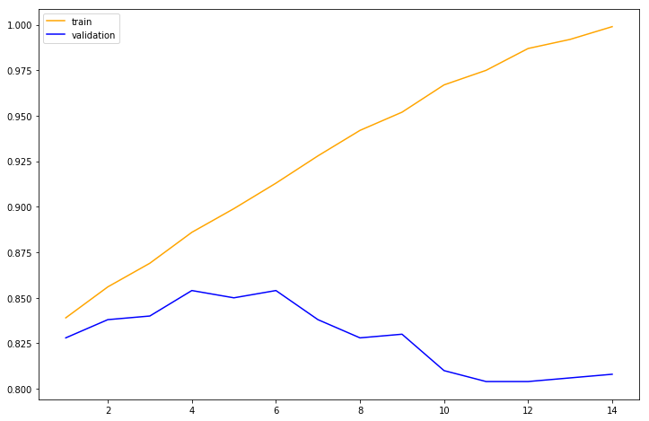

```python
train_scores = []
validation_scores = []
for max_depth in range(1,15):
    decision_tree = DecisionTreeClassifier(random_state=123, max_depth=max_depth)
    decision_tree.fit(X_train, Y_train)
    train_scores.append(decision_tree.score(X_train, Y_train))
    validation_scores.append(decision_tree.score(X_val, Y_val))

#print(train_scores, validation_scores)
plt.figure(figsize=(12,8))
plt.plot(range(1,15), train_scores, c='orange', label='train')
plt.plot(range(1,15), validation_scores, c='blue', label='validation')
plt.legend(loc='best')
```

### 7. Choose the most appropriate tree depth and justify your choice. What do you think of this classifier?

Based on above figure where we are plotting train and test accuracy against `max_depth`. We can clearly see that till `max_depth` of `4`, accuracy of train and valdation sets are clearly improving. But after that train accuracy is improving but validation accuracy is suffering hence model is `OVERFITTING` train data.

We can say that `max_depth=4` is right value for this data.

### 8. Retrain the best classifier using all the samples from both the training and the validation set. Estimate the out-of-sample accuracy of this classifier on the test set. Discuss what you observe.

Below we are training classifier using both train and validation data. We are setting `max_depth=4` as we have found out above. We can see that accuracy on this new train(train+validation) set and test set is almost same as above. Hence we have found out optimal vaue for `max_depth` parameter which is `4`.

We can clearly see that there is not much difference in accuracy of train and test set which suggest that we have found out generalized model which is neighter overfitting nor underfitting.

```python
decision_tree = DecisionTreeClassifier(random_state=123, max_depth=4)

decision_tree.fit(np.vstack([X_train, X_val]), np.hstack([Y_train,Y_val]))

print('Decision Tree Train Accuracy : ', decision_tree.score(np.vstack([X_train, X_val]), np.hstack([Y_train,Y_val])))
print('Decision Tree Test Accuracy : ', decision_tree.score(X_test, Y_test))
```

```
Decision Tree Train Accuracy :  0.872
Decision Tree Test Accuracy :  0.866
```

### 9. Retrain the best classifier on all samples (including the test set) and describe the tree that you obtain (e.g. via visualisation, or via textual description).

Below we are training model using all train,validation and test dataset with `max_depth=4` which we found out above.

We are also plotting decision tree after model is trained. We can clearly see that even on full data we are getting same accuracy as that of above model which suggests that `max_depth=4` is optimal parameter setting for this dataset.

```python
decision_tree = DecisionTreeClassifier(random_state=123, max_depth=4)

decision_tree.fit(np.vstack([X_train, X_val, X_test]), np.hstack([Y_train,Y_val, Y_test]))
print('Decision Tree Train Accuracy : ', decision_tree.score(np.vstack([X_train, X_val, X_test]), np.hstack([Y_train,Y_val, Y_test])))
```

```
Decision Tree Train Accuracy :  0.8725
```

[figure not shown]

```python
dot_data = StringIO()
export_graphviz(decision_tree, out_file=dot_data,
                filled=True, rounded=True,
                special_characters=True,
                feature_names= ['loanAmount','selectiveCollege','sex','field_BUSINES','field_HUMANITIES','field_STEM','graduationYear_2005','graduationYear_2006','graduationYear_2007','graduationYear_2008','graduationYear_2009','graduationYear_2010','graduationYear_2011','graduationYear_2012','graduationYear_2013','graduationYear_2014'],
                class_names=['yes','no'])
graph = pydotplus.graph_from_dot_data(dot_data.getvalue())
Image(graph.create_png())
```